# GEOG 6000 Lab Plotting with ggplot2

## Barcharts

Two types of barchart can be produced by **ggplot2**. By default, the barcharts are presented as summary of the variable of interest. With factor or categorical variables, this is simply a count of each category. For example:

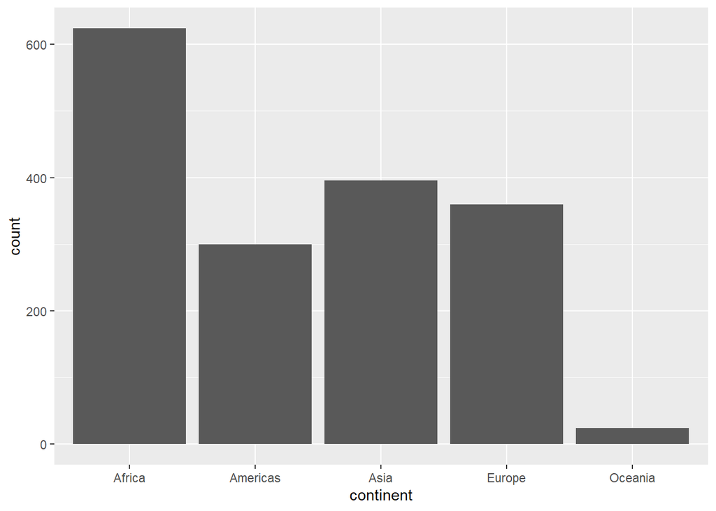

```r
myplot <- ggplot(gapdata, aes(x = continent))

myplot + geom_bar()
```

Often, however, we want to use some precalculated value for the height of the bar. In the Virginia death rate dataset, for example, the death rates have already been calculated by age and demographic class. To plot death rates per age groups, we can do the following:

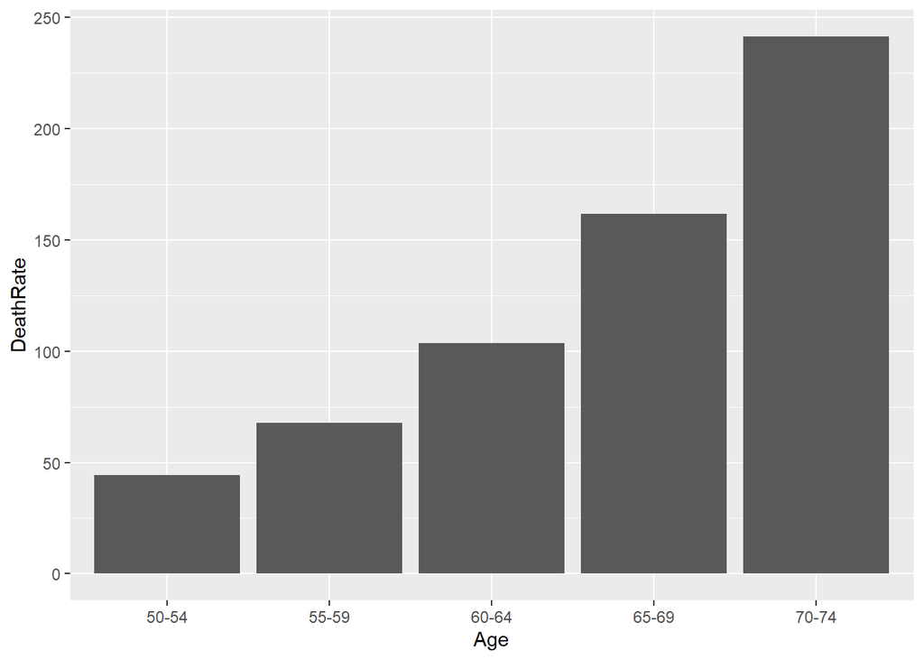

```r
myplot <- ggplot(VADeaths2, aes(x = Age, y = DeathRate))

myplot + geom_bar(stat = "identity")
```

We can split the plot into the different demographic groups. As before, we can do this in two ways. First, by including the demographic group as a fill in the aesthetic setup:

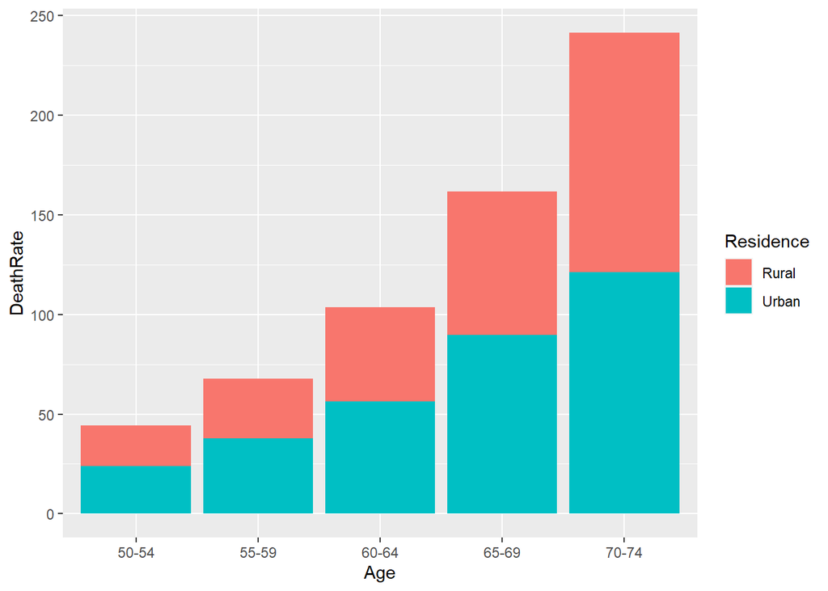

```r
myplot + geom_bar(aes(fill = Residence), stat = "identity")
```

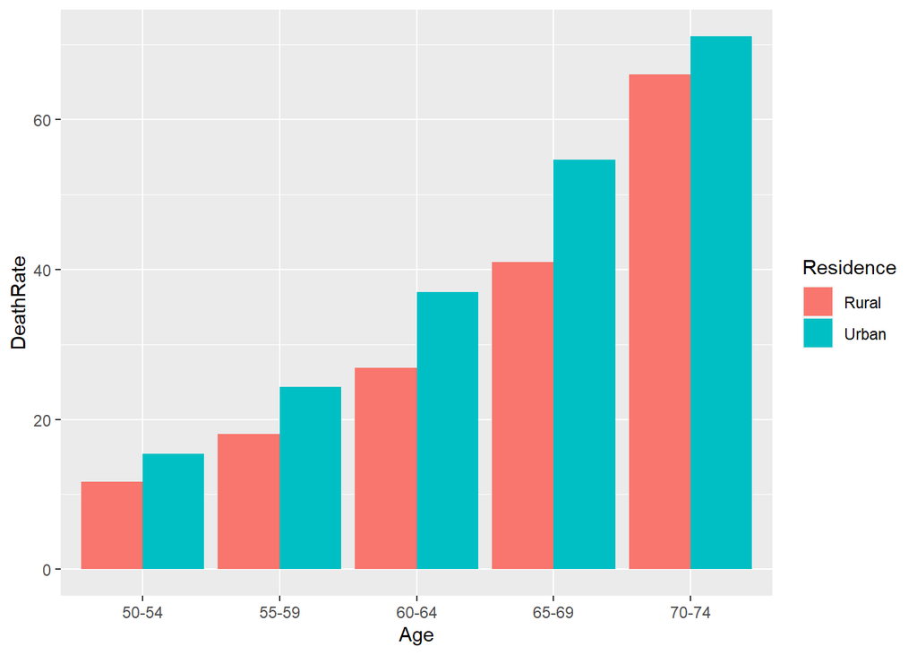

```r
myplot + geom_bar(aes(fill = Residence), stat = "identity", position = "dodge")
```

Second, by using faceting the data using `facet_wrap()` (we also use `coord_flip()` to make the bars horizontal):

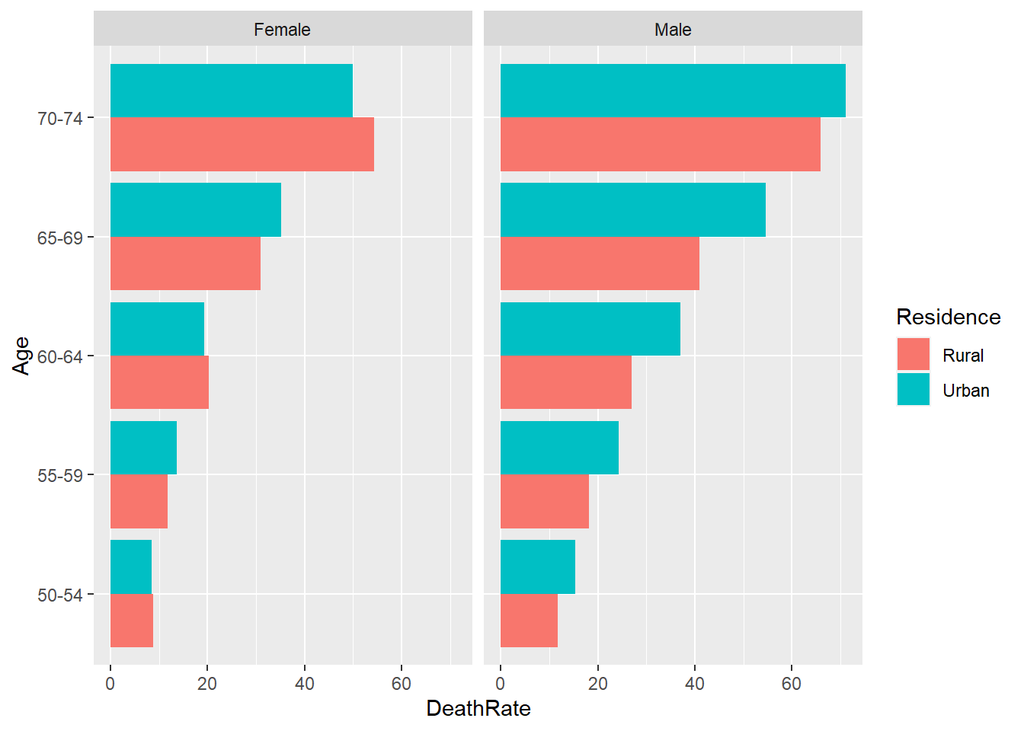

```r
myplot +
  geom_bar(aes(fill = Residence), stat = "identity", position = "dodge") +
  facet_wrap(~ Gender) +
  coord_flip()
```